# Machine Learning Project

Oleg Slinin

October 31, 2016

## Introduction

The following is an application of machine learning to evaluate the execution of exercise performance based on sensor data.

## Approach

We use in sample accuracy to evaluate machine learning models for this task.

We save the variables in each chunk of R code to binary files and use those files if possible, in order to avoid rerunning code unnecessarily.

There are four figures in the data exploration section. In the rest of the document, accuracy and coefficients are shown for different models as output from the chunks of R code.

## Data

The Weight Lifting Exercise (WLE) dataset used is from:

Velloso, E.; Bulling, A.; Gellersen, H.; Ugulino, W.; Fuks, H. Qualitative Activity Recognition of Weight Lifting Exercises. Proceedings of 4th International Conference in Cooperation with SIGCHI (Augmented Human ’13) . Stuttgart, Germany: ACM SIGCHI, 2013.

The data is available at http://groupware.les.inf.puc-rio.br/

```r
suppressPackageStartupMessages(library("caret"))
suppressPackageStartupMessages(library("mvbutils"))
if (!exists("traind")) if (file.exists("train.RData")) load("train.RData")
if (!exists("traind")){
  traind<<-read.csv("pml-training.csv",row.names=1, na.strings=c("NA", "", "#DIV/0!"))
  testd<<-read.csv("pml-testing.csv",row.names=1, na.strings=c("NA", "", "#DIV/0!"))
  keep.cols=names(traind) #columns to include in the model.
  save(traind, testd, keep.cols, file="train.RData")
}
```

## Explanatory Data Analysis

Most data is sensor readings, which we can readily include in variable selection, dimension reduction and model fitting. The exception is the variable columns.

```r
names(traind)[sapply(traind, class)=="factor"]
```

```
## [1] "user_name"      "cvtd_timestamp" "new_window"     "classe"
```

The test data has user_name, so we will use the field, and the analysis will only apply to the users in the dataset.

There are 3 time stamp columns: raw_timestamp_part_1, raw_timestamp_part_2, and cvtd_timestamp. The definition of these columns is not available, so we explore the data to see if they are redundant. The first two columns do not seem to be correlated, so we will use both fields:

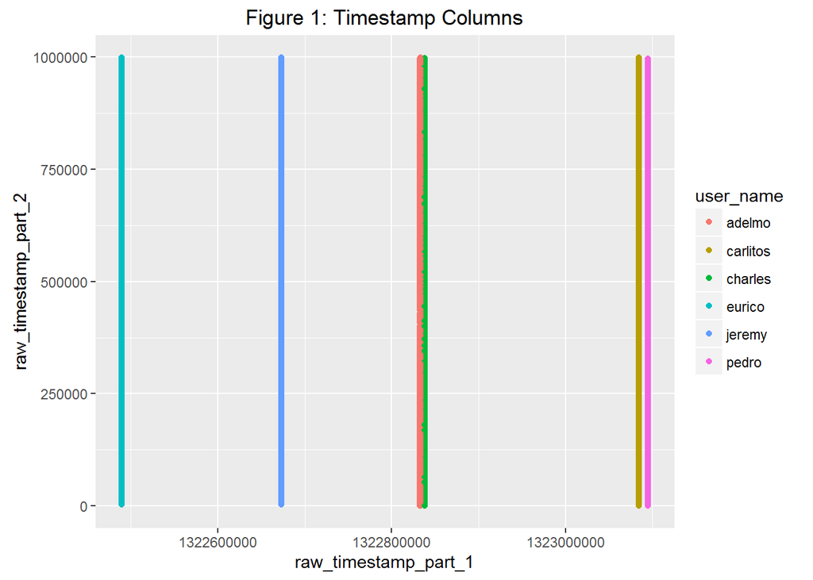

```r
suppressPackageStartupMessages(library(ggplot2))

qplot(raw_timestamp_part_1, raw_timestamp_part_2, data=traind,
      color=user_name, main = "Figure 1: Timestamp Columns")
```

To see the result more clearly, we look at one user_name.

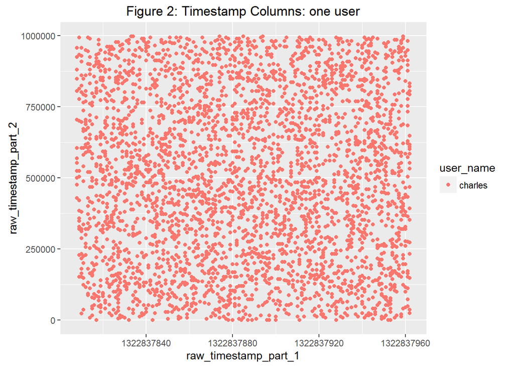

```r
qplot(raw_timestamp_part_1, raw_timestamp_part_2, color=user_name,
      data=traind[traind$user_name=="charles",], main = "Figure 2: Timestamp Columns: one user")
```

The field cvtd_timestamp seems to be a less granular version of raw_timestamp_part_1.

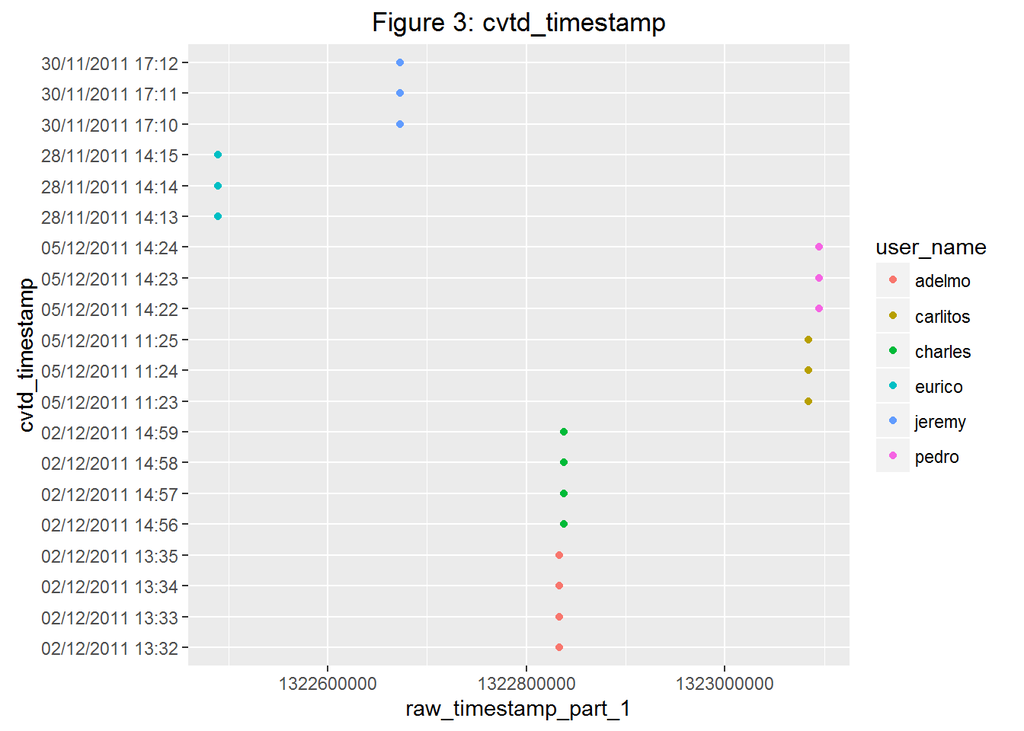

```r
qplot(raw_timestamp_part_1, cvtd_timestamp, data=traind, color=user_name,
      main = "Figure 3: cvtd_timestamp")
```

To see the result more clearly, we look at one user_name.

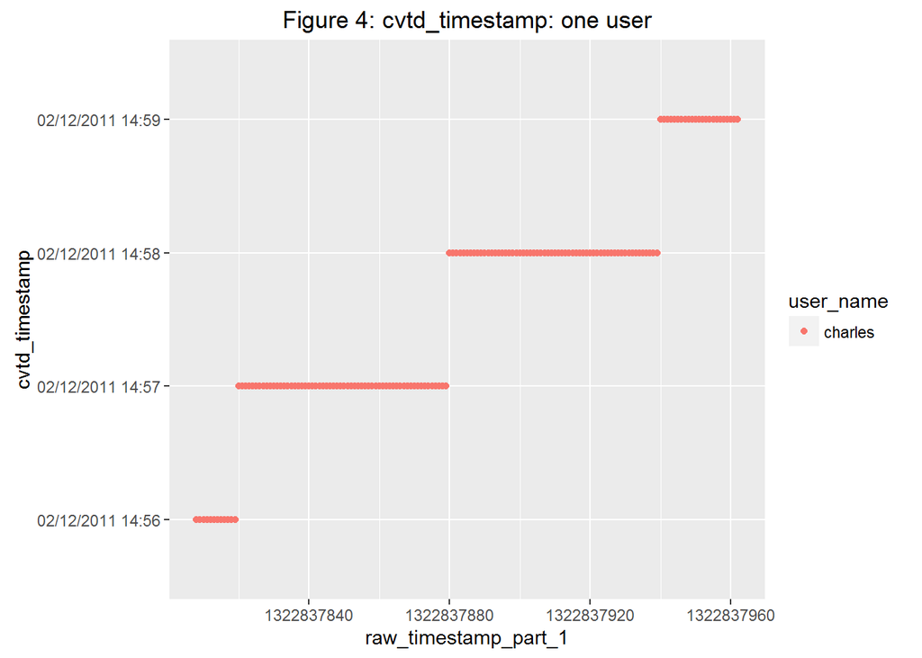

```r
qplot(raw_timestamp_part_1, cvtd_timestamp, color=user_name,
      data=traind[traind$user_name=="charles",], main = "Figure 4: cvtd_timestamp: one user")
```

cvtd_timestamp seems to be an indicator of the exercise performed, so we will not remove it. Even though it is correlated with raw_timestamp_part_1, it seems to have additional information.

## Data cleaning

We will remove columns that are almost completely NA and other low variance variables. We use the caret::newarZeroVar() function to filter out variables with near zero variance.

```r
if (!exists("zero.vars")) if (file.exists("zero.var.RData")) load("zero.var.RData")
if (!exists("zero.vars")){
  zero.vars = nearZeroVar(traind[,keep.cols], saveMetrics = T)
  drop.cols <- names(traind[,keep.cols])[zero.vars$nzv]
  keep.cols=keep.cols%except%drop.cols
  save(zero.vars, drop.cols, keep.cols, file="zero.var.RData")
}
```

There are still NAs in the data, and most prediction algorithms cannot handle it. We will use knnImpute method to preProcess the data and estimate missing data from the averages of the k nearest neightbors.

```r
if (!exists("preObj")) if (file.exists("preObj.RData")) load("preObj.RData")
if (!exists("preObj")){
  preObj <- preProcess(traind[,keep.cols],method=c("knnImpute","center","scale"))
  trainp <- predict(preObj, traind[,keep.cols])
  save(preObj, trainp, file="preObj.RData")
}
```

## Trees

We will try to fit a tree model using the rpart package. Trees are generally useful for splitting variables into multiple groups, which is the task here.

```r
suppressPackageStartupMessages(library(rpart))

if (!exists("modFit.rpart")) if (file.exists("modFit.rpart.RData")) load("modFit.rpart.RData")
if (!exists("modFit.rpart")){
  modFit.rpart <- train(classe~ .,data=trainp,method="rpart")
  save(modFit.rpart, file="modFit.rpart.RData")
}
print(modFit.rpart$finalModel)
```

```
## n= 19622
##
## node), split, n, loss, yval, (yprob)
##       * denotes terminal node
##
##  1) root 19622 14042 A (0.28 0.19 0.17 0.16 0.18)
##    2) roll_belt< 1.053267 17977 12411 A (0.31 0.21 0.19 0.18 0.11)
##      4) kurtosis_yaw_arm>=0.591548 1966   161 A (0.92 0.032 0.036 0.0092 0.0056) *
##      5) kurtosis_yaw_arm< 0.591548 16011 12250 A (0.23 0.23 0.21 0.2 0.12)
##       10) raw_timestamp_part_1< -1.646819 855     0 A (1 0 0 0 0) *
##       11) raw_timestamp_part_1>=-1.646819 15156 11421 B (0.19 0.25 0.22 0.21 0.13)
##         22) cvtd_timestamp02/12/2011 13:33>=0.5 1304   333 A (0.74 0.26 0 0 0) *
##         23) cvtd_timestamp02/12/2011 13:33< 0.5 13852 10450 B (0.14 0.25 0.24 0.23 0.14)
##           46) magnet_dumbbell_z< -0.4969407 4996  3437 A (0.31 0.31 0.097 0.22 0.058)
##             92) raw_timestamp_part_1< 0.05235618 889    42 A (0.95 0.039 0.0079 0 0) *
##             93) raw_timestamp_part_1>=0.05235618 4107  2599 B (0.17 0.37 0.12 0.27 0.071) *
##           47) magnet_dumbbell_z>=-0.4969407 8856  5988 C (0.042 0.21 0.32 0.23 0.19)
##             94) magnet_dumbbell_x< -0.3473971 6238  3538 C (0.058 0.13 0.43 0.26 0.12) *
##             95) magnet_dumbbell_x>=-0.3473971 2618  1556 B (0.0046 0.41 0.064 0.17 0.36) *
##    3) roll_belt>=1.053267 1645    14 E (0.0085 0 0 0 0.99) *
```

```r
print(confusionMatrix(trainp$classe, predict(modFit.rpart,trainp))$overall['Accuracy'])
```

```
##  Accuracy
## 0.5799103
```

Accuracy is low, and the tree traversal model does not seem to be the best way to model these largely numerical covariates.

## Linear Discriminant Analysis

We will now fit a linear discriminant analysis (LDA) model using the MASS package through the caret package. LDA is well suited for the problem, because the variables are largely numerical, and assuming that they are drawn from some parametric distribution should not be reasonable.

```r
suppressPackageStartupMessages(library(MASS))

if (!exists("modFit.lda")) if (file.exists("modFit.lda.RData"))  load("modFit.lda.RData")
if (!exists("modFit.lda")){
  modFit.lda <- train(classe~ .,data=trainp,method="lda")
  save(modFit.lda, file="modFit.lda.RData")
}
print(modFit.lda$finalModel$xNames[1:30])
```

```
##  [1] "user_namecarlitos"              "user_namecharles"
##  [3] "user_nameeurico"                "user_namejeremy"
##  [5] "user_namepedro"                 "raw_timestamp_part_1"
##  [7] "raw_timestamp_part_2"           "cvtd_timestamp02/12/2011 13:33"
##  [9] "cvtd_timestamp02/12/2011 13:34" "cvtd_timestamp02/12/2011 13:35"
## [11] "cvtd_timestamp02/12/2011 14:56" "cvtd_timestamp02/12/2011 14:57"
## [13] "cvtd_timestamp02/12/2011 14:58" "cvtd_timestamp02/12/2011 14:59"
## [15] "cvtd_timestamp05/12/2011 11:23" "cvtd_timestamp05/12/2011 11:24"
## [17] "cvtd_timestamp05/12/2011 11:25" "cvtd_timestamp05/12/2011 14:22"
## [19] "cvtd_timestamp05/12/2011 14:23" "cvtd_timestamp05/12/2011 14:24"
## [21] "cvtd_timestamp28/11/2011 14:13" "cvtd_timestamp28/11/2011 14:14"
## [23] "cvtd_timestamp28/11/2011 14:15" "cvtd_timestamp30/11/2011 17:10"
## [25] "cvtd_timestamp30/11/2011 17:11" "cvtd_timestamp30/11/2011 17:12"
## [27] "num_window"                     "roll_belt"
## [29] "pitch_belt"                     "yaw_belt"
```

```r
print(confusionMatrix(trainp$classe, predict(modFit.lda,trainp))$overall['Accuracy'])
```

```
##  Accuracy
## 0.8782489
```

The accuracy is fairly high. The model has also created indicated variables for the user_name, and cvtd_timestamp, which is necessary for variable data, since the numerical value of the variable is meaningless.

## Cross-Validation

We will use cross validation to attempt to improve out of sample performance, becuase the accuracy measure of the model above will be too optimistic for out of sample data.

```r
fitControl <- trainControl(method = "cv", #cross validation
                           number = 100 # fold cross-validation so variance not too large
)
if (!exists("modFit.lda.cv")) if(file.exists("modFit.lda.cv.RData")) load("modFit.lda.cv.RData")
if (!exists("modFit.lda.cv")){
  modFit.lda.cv <- train(classe~ .,data=trainp,method="lda", trainControl=fitControl)
  save(modFit.lda.cv, file="modFit.lda.cv.RData")
}
#print(modFit.lda.cv$finalModel) #variables handled appropriately
print(confusionMatrix(trainp$classe, predict(modFit.lda.cv,trainp))$overall['Accuracy'])
```

```
##  Accuracy
## 0.8782489
```

## Dimension reduction

There still 123 variables, and we will try to use PCA to reduce this number. This preprocessing procedure will calculate a linear transformation of the variables to capture 90% of the variation in the variables, other than user_name. We first calculate the number of principal components necessary, and then use this to fit the LDA model. We also normalize the data in the preprocessing step by centering and scaling, in order to help the model calibrate.

```r
if (!exists("preObj.pca")) if (file.exists("pca.RData")) load("pca.RData")
if (!exists("preObj.pca")){
  #calculate how many principal components we need
  trainp1 <- train[,keep.cols[6:(length(keep.cols)-1)]]
  preObj <- preProcess(trainp1,method=c("knnImpute","center","scale")) #,method=c()
  trainp1 <- predict(preObj, trainp1)
  PC=prcomp(trainp1,scale=T)
  n.pca=min(which(PC$importance[3,]>=.9))
  x=PC$sdev^2
  x=x[order(x,decreasing=T)]
  x2=cumsum(x)/sum(x)
  n.pca=min(which(x2>.9))

  #fit an LDA model with PCA.
  preObj.pca <- preProcess(traind[,keep.cols],method=c("knnImpute", "pca", "center", "scale"),
                           pcaComp=n.pca)
  train.pca <- predict(preObj.pca, traind[,keep.cols])
  modFit.lda.pca <- train(classe~ .,data=train.pca,method="lda") #missing values
  save(n.pca, preObj.pca, train.pca, modFit.lda.pca, file="pca.RData")
}
print(paste(n.pca, " principal components capture 90% of the variance in the variables"))
```

```
## [1] "30  principal components capture 90% of the variance in the variables"
```

```r
#print(modFit.lda.pca$finalModel) #variables handled appropriately
print(confusionMatrix(trainp$classe, predict(modFit.lda.pca,train.pca))$overall['Accuracy'])
```

```
##  Accuracy
## 0.7640404
```

The PCA model is less accurate, but faster, since it uses fewer variables.

## Ensemble model

We can try to combine predictors to see if in-sample performance improves. We use random forests to combine predictors of our previous models.

```r
if (!exists("combinedTrainData")) if (file.exists("ensemble.RData")) load("ensemble.RData")
if (!exists("combinedTrainData")){
  combinedTrainData <- data.frame(
    classe=trainp$classe,
    lda=      predict(modFit.lda    ,trainp),
    lda.pca = predict(modFit.lda.pca,train.pca),
    rpart =   predict(modFit.rpart  ,trainp)
  )

  comb.fit <- train(classe ~.,method="rf",data=combinedTrainData, prox=F) #The ensemble model does not calibrate unless prox=F.
  combinedTrainData$combined.pred = predict(comb.fit, combinedTrainData)
  save(combinedTrainData,comb.fit, file= "ensemble.RData")
}
print(  confusionMatrix(combinedTrainData$classe, combinedTrainData$combined.pred)$overall['Accuracy'])
```

```
##  Accuracy
## 0.8801345
```

```r
print(  sapply(combinedTrainData, function(x) mean(x==combinedTrainData$classe)))
```

```
##        classe           lda       lda.pca         rpart combined.pred
##     1.0000000     0.8782489     0.7640404     0.5799103     0.8801345
```

The in-sample accuracy goes up .2% over the LDA model, so we will use the ensemble model.

We do not provide results for boosting or regularization feature selection because the models GBM and lars models through caret did not calibrate. However, these would also be reasonable candidates for this classification problem.

## Test data

We will now apply the LDA model to the test data.

```r
suppressWarnings(suppressPackageStartupMessages(library(randomForest)))

if (!exists("combinedTestData")) if (file.exists("modFit.lda.test.RData"))  load("modFit.lda.test.RData")
if (!exists("combinedTestData")){
  # apply the transformation in preObj to test data: knnImpute, center, scale; subset to keep.cols
  keep.cols1 = keep.cols %except% "classe"
  testp <- predict(preObj, testd[,keep.cols1])
  test.pca <- predict(preObj.pca, testd[,keep.cols1])

  #run the model on test data.
  combinedTestData <- data.frame(
    lda=      predict(modFit.lda.cv ,testp),
    lda.pca = predict(modFit.lda.pca,test.pca),
    rpart =   predict(modFit.rpart  ,testp)
  )
  ensemble.test <- predict(comb.fit, combinedTestData)
  combinedTestData$ensemble = ensemble.test
  save(combinedTestData, ensemble.test, file="modFit.lda.test.RData")
}
print(combinedTestData)
```

```
##    lda lda.pca rpart ensemble
## 1    B       B     B        B
## 2    A       C     A        A
## 3    B       C     C        B
## 4    A       A     A        A
## 5    A       A     A        A
## 6    E       E     C        E
## 7    D       D     C        D
## 8    C       B     C        C
## 9    A       A     A        A
## 10   A       A     A        A
## 11   B       B     C        B
## 12   C       C     C        C
## 13   B       B     B        B
## 14   A       A     A        A
## 15   E       E     C        E
## 16   E       E     B        E
## 17   A       A     A        A
## 18   B       B     B        B
## 19   B       B     B        B
## 20   B       B     B        B
```

The ensemble model always agrees with the LDA model.